# Исследовательская работа: Мэтчинг товаров

## Введение

### Описание проекта

Нам доступны некие закодированные данные, мы не знаем какие характеристики товаров они выражают, можем только провести их анализ. Итак, нам доступно следующее:

- `base.csv`. Датасет со всеми доступными товарами. Анонимизированный набор товаров. Каждый товар представлен как уникальный id (0-base, 1-base, 2-base) и вектор признаков размерностью 72.
- `train.csv`. Обучающий датасет. Каждая строчка - один товар, для которого известен уникальный id (0-query, 1-query, …) , вектор признаков И id товара из base.csv, который максимально похож на него (по мнению экспертов).
- `validation.csv`. Валидационный датасет. Датасет с товарами (уникальный id и вектор признаков), для которых надо найти наиболее близкие товары из `base.csv`.
- `validation_answer.csv`. Правильные ответы к валидационной выборки.

Датасет base содержат индексы товаров, обезличенные признаки товаров. Будем считать “правильные ответы” индексами наиболее подходящих товаров-аналогов (кроме валидационного датасета - для него “правильные ответы” содержатся в отдельном файле). Есть возможность выбрать, работать с более объемными датасетами (более 2 Гб), либо выбрать уменьшенный вариант (~10% от исходной версия датасета), ниже это можно выбрать поправив соответствующую константу.

**Задача:**  
разработать алгоритм, который для всех товаров из `validation.csv` предложит несколько вариантов наиболее похожих товаров из base. Оценить качество алгоритма по метрике `accuracy@5`, попытаться добиться наилучшей метрики подбирая разные рабочие параметры.

### Цели

- Изучить имеющиеся данные и подготовить их для создания алгоритма
- Разработать алгоритм поиска похожих товаров и оценить его значение метрики accuracy@5 на валидационном датасете.

## Настройка среды выполнения

*Внимание! Установка системных библиотек работает только в удаленных сервисах по типу google colab, также можно запустить команды локально под ОС Linux, но для этого нужны права администратора!*

```python
## LLVM OpenMP
!apt -q install libomp-dev
```

[output not shown]

## Загрузка библиотек

```python
## Обертки для данных
import pandas as pd
import numpy as np

## Разное, вспомогательное
import os, requests
from urllib.parse import urlencode
import zipfile
from time import perf_counter

## Графики, визуализация
import matplotlib.pyplot as plt
import seaborn as sns

## Корреляционный анализ
!pip install phik -q
from phik import phik_matrix

## Методы и классы для работы с моделями
# Масштабирование данных (скейлеры)
from sklearn.preprocessing import RobustScaler

## Модели
# FAISS
!pip -q install faiss-cpu --no-cache
#!pip -q install faiss-gpu
import faiss

##
from warnings import simplefilter
```

```
     ━━━━━━━━━━━━━━━━━━━━━━━━━━━━━━━━━━━━━━━━ 686.1/686.1 kB 8.2 MB/s eta 0:00:00
     ━━━━━━━━━━━━━━━━━━━━━━━━━━━━━━━━━━━━━━━━ 27.0/27.0 MB 137.8 MB/s eta 0:00:00
```

## Установка параметров проекта

```python
pd.options.mode.chained_assignment = None
pd.set_option('display.max_columns', None)
```

## Константы проекта

```python
# Константа для одинаковой псевдослучайности
RANDOM_STATE = 59

# Выбрать датасет большей размерности?
OPTION_IS_LARGE_DATASET_USE = False

# Тетрадка выполняестя на локальной машине? (Не в Google Colab или подобном сервисе)
OPTION_IS_LOCAL_USE = False

# Количество кандидатов найденных документов из base
OPTION_N_CANDIDATS = 5
```

## Вспомогательные функции загрузки данных

### Функция загрузчик датасетов

- Функция примет ** логическое значение - использовать большой датасет? True | False
- Функция загрузит файл датасетов и распакует их в текущую директорию выполняемой тетради для дальнейшего использования в их проекте.

```python
def dataset_downloader(use_large_dataset:bool=False, local_use:bool=False):
    '''
    Loads working datasets and unpacks them to disk in the current project
    directory.

    Arguments:
    - use_large_dataset:bool. Set to true if you need to work with a larger
      dataset.
    - local_use:bool. If executed remotely, for example, in the Google Colab
      service, you will return False; if executed locally, need set True.
    '''
    if not use_large_dataset:
      public_key = 'https://disk.yandex.ru/d/YQElc_cNQQLSOw'
    else:
      public_key = 'https://disk.yandex.ru/d/BBEphK0EHSJ5Jw'

    base_url = 'https://cloud-api.yandex.net/v1/disk/public/resources/download?'

    final_url = base_url + urlencode(dict(public_key=public_key))
    response = requests.get(final_url)
    download_url = response.json()['href']

    download_response = requests.get(download_url)

    status_code = download_response.status_code

    if status_code != 200:
      return status_code

    else:
      zip_file_path = None
      if local_use:
        zip_file_path = 'data.zip'
      else:
        zip_file_path = '/content/data.zip'

      with open(zip_file_path, 'wb') as f:
        f.write(download_response.content)

      zip_file_path_cart = (zip_file_path)

      with zipfile.ZipFile(zip_file_path_cart, 'r') as zip_ref:
        zip_ref.extractall()

      if os.path.exists(zip_file_path):
        os.remove(zip_file_path)

    return status_code
```

## Загрузка данных

```python
%%time
status_code = dataset_downloader(OPTION_IS_LARGE_DATASET_USE, OPTION_IS_LOCAL_USE)

if status_code != 200:
  raise Exception(f'Fail download dataset, status_code: {status_code}')
```

```
CPU times: user 3.29 s, sys: 965 ms, total: 4.26 s
Wall time: 13.2 s
```

## Первичное знакомство с данными

### Вспомогательные функции

#### Функция вывода пропусков в процентном соотношении от данных

- Функция примет ** датасет pandas
- Функция выведет на экран пропуски только по тем столбцам где они имеются.

```python
def show_miss(data:pd.DataFrame):
    '''
    Display only the columns with gaps and the number of gaps.

    Arguments:
    - data:pd.DataFrame. Dataframe pandas with analyzed data.
    '''
    miss_abs = data.isna().sum()
    miss = ((data.isna().sum() / len(data)).round(3) * 100)
    miss = miss[miss > 0.0]
    miss_abs = miss_abs[miss_abs > 0]
    miss_df = pd.DataFrame(
        {
            'feature':miss.index,
            'miss':miss_abs.values,
            'miss_pr':miss.values
        }
    ).set_index('feature').sort_values(by='miss', ascending=False)
    if len(miss) == 0:
        print("\nПропуски отсутствуют.")
    else:
        print("\nИмеющиеся пропуски:")
        display(miss_df)
```

#### Функция для открытия датасетов с первичным анализом данных.

```python
def load_dataset(path:str, index_col=None, dtype=None, is_analysis=False):
    '''
    Load the dataset and you can additionally display an initial assessment
    of the data.

    Arguments:
    - path:str. Path to the file that needs to be loaded.
    - index_col. Hashable, Sequence of Hashable or False, optional
        Column(s) to use as row label(s), denoted either by column labels or
        column indices. If a sequence of labels or indices is given, MultiIndex
        will be formed for the row labels.
        Note: index_col=False can be used to force pandas to not use the first
        column as the index, e.g., when you have a malformed file with
        delimiters at the end of each line. (Default: None)
    - dtype. A dictionary to explicitly indicate to columns their type
        (Default: None)
    - is_analysis. A flag that includes the output of information for initial
        acquaintance with the data. (Default: False)
    '''
    if os.path.exists(path):
        df = pd.read_csv(path, index_col=index_col, dtype=dtype)
        print(f'Файл "{path}" успешно загружен.')
        if is_analysis:
          display(df.describe())
          display(df.head())
          print("Размерность:", df.shape)
          df.info()
          show_miss(df)
        return df
    else:
        raise SystemExit(f'Ошибка, файл "{path}" не найден!')
```

### Открытие данных

*Для уменьшения использования ОЗУ, поменяем в колонках тип `float64` по умолчанию на `float32`.*

```python
types = {}
for i in range(0, 72):
    types[str(i)] = 'float32'
```

#### Открытие и первичный анализ множества Base

```python
df_base = load_dataset("base.csv", index_col='Id', dtype=types)
```

```
Файл "base.csv" успешно загружен.
```

#### Открытие и первичный анализ множества Train

```python
df_train = load_dataset("train.csv", index_col='Id', dtype=types, is_analysis=True)
if 'Target' in df_train.columns:
  targets = df_train["Target"]
  df_train.drop("Target", axis=1, inplace=True)
```

```
Файл "train.csv" успешно загружен.
```

|  | 0 | 1 | 2 | 3 | 4 | 5 | 6 | 7 | 8 | 9 | 10 | 11 | 12 | 13 | 14 | 15 | 16 | 17 | 18 | 19 | 20 | 21 | 22 | 23 | 24 | 25 | 26 | 27 | 28 | … |
| --- | --- | --- | --- | --- | --- | --- | --- | --- | --- | --- | --- | --- | --- | --- | --- | --- | --- | --- | --- | --- | --- | --- | --- | --- | --- | --- | --- | --- | --- | --- |
| count | 9999.000000 | 9999.000000 | 9999.000000 | 9999.000000 | 9999.000000 | 9999.000000 | 9999.000000 | 9999.000000 | 9999.000000 | 9999.000000 | 9999.000000 | 9999.000000 | 9999.000000 | 9999.000000 | 9999.000000 | 9999.000000 | 9999.000000 | 9999.000000 | 9999.000000 | 9999.000000 | 9999.000000 | 9999.000000 | 9999.000000 | 9999.000000 | 9999.000000 | 9999.000000 | 9999.000000 | 9999.000000 | 9999.000000 | … |
| mean | -85.469574 | 7.608016 | -43.886494 | -146.204147 | 111.979584 | -73.679420 | -443.890747 | 21.820551 | 123.107399 | 126.418045 | -140.639114 | -69.334526 | -42.286949 | 5.943080 | 149.113464 | -23.937223 | -1.952591 | -13.265595 | -138.188843 | -79.180061 | -97.464981 | 1299.001709 | -3.538495 | 56.512051 | 23.047552 | 741.740845 | -64.888275 | 16.298483 | -86.455231 | … |
| std | 25.986217 | 4.985728 | 39.318615 | 20.309633 | 47.599873 | 28.743811 | 281.494324 | 66.450439 | 6.418815 | 64.858192 | 41.384533 | 51.226486 | 40.946884 | 37.525078 | 34.054665 | 13.015724 | 20.950773 | 54.944038 | 48.968388 | 0.777864 | 28.254011 | 371.742767 | 50.212677 | 35.451912 | 41.189892 | 193.164261 | 63.593674 | 4.813034 | 48.752132 | … |
| min | -173.032562 | -11.560507 | -187.292633 | -219.724792 | -71.243347 | -184.962448 | -791.443909 | -250.681335 | 99.001770 | -113.104599 | -287.202637 | -344.520569 | -201.855179 | -128.040482 | 21.577286 | -77.179039 | -70.050766 | -222.327652 | -329.597717 | -82.252945 | -228.985535 | 136.900452 | -174.593445 | -75.980484 | -120.500656 | -61.640877 | -318.192688 | -4.305775 | -269.041626 | … |
| 25% | -103.445763 | 4.178606 | -69.990780 | -160.032883 | 79.712387 | -93.620304 | -757.628754 | -21.344349 | 118.787720 | 81.959694 | -168.315628 | -103.138321 | -70.147209 | -19.432253 | 126.442184 | -32.289482 | -16.294177 | -49.630930 | -171.156921 | -79.681541 | -115.316513 | 1248.126221 | -37.116690 | 32.634457 | -5.998924 | 813.770081 | -106.627327 | 13.131955 | -119.623573 | … |
| 50% | -85.177101 | 7.592032 | -43.009907 | -146.576218 | 112.233475 | -74.031082 | -517.673340 | 22.233669 | 123.002785 | 126.280350 | -140.114014 | -68.798584 | -41.109615 | 6.030684 | 150.224747 | -23.806658 | -2.042259 | -12.335911 | -138.570480 | -79.155266 | -96.680939 | 1507.231323 | -3.494238 | 56.087132 | 23.236225 | 813.770081 | -65.236969 | 16.366844 | -87.253204 | … |
| 75% | -67.437847 | 10.989735 | -17.223701 | -132.675850 | 144.052643 | -54.168715 | -203.437622 | 66.437386 | 127.499310 | 169.959885 | -112.591171 | -35.205748 | -14.515329 | 31.544528 | 172.527870 | -15.527121 | 11.982494 | 24.029415 | -106.151581 | -78.655270 | -78.146217 | 1507.231323 | 30.374752 | 79.851372 | 52.221823 | 813.770081 | -22.825771 | 19.539021 | -53.618279 | … |
| max | 5.052292 | 26.741890 | 134.859802 | -71.194679 | 297.368622 | 31.378914 | 109.632034 | 261.413422 | 145.178467 | 353.214966 | 14.706146 | 133.851593 | 89.709702 | 134.725159 | 278.276184 | 30.950819 | 88.695938 | 189.463425 | 82.683807 | -76.700424 | 0.243759 | 1556.087036 | 193.884308 | 193.120834 | 148.891632 | 845.476562 | 202.053894 | 35.141838 | 107.757996 | … |

| Id | 0 | 1 | 2 | 3 | 4 | 5 | 6 | 7 | 8 | 9 | 10 | 11 | 12 | 13 | 14 | 15 | 16 | 17 | 18 | 19 | 20 | 21 | 22 | 23 | 24 | 25 | 26 | 27 | 28 | … |
| --- | --- | --- | --- | --- | --- | --- | --- | --- | --- | --- | --- | --- | --- | --- | --- | --- | --- | --- | --- | --- | --- | --- | --- | --- | --- | --- | --- | --- | --- | --- |
| 109249-query | -24.021454 | 3.122524 | -80.947525 | -112.329994 | 191.090179 | -66.903130 | -759.626038 | -75.284454 | 120.551491 | 131.131699 | -149.211060 | -102.312210 | 21.387623 | 11.277594 | 143.221405 | -22.011570 | -3.618249 | -16.005480 | -133.382278 | -78.893562 | -65.690529 | 407.773560 | -11.660624 | 67.008148 | 24.975033 | 813.770081 | 40.051064 | 17.933155 | -75.435745 | … |
| 34137-query | -82.033577 | 8.115866 | -8.793022 | -182.972107 | 56.645336 | -52.597610 | -55.720337 | 130.059250 | 129.383347 | 76.202881 | -137.799423 | 33.301651 | -2.868191 | -34.318771 | 189.064789 | -19.337549 | -14.208210 | -71.110245 | -157.748138 | -78.700691 | -91.741875 | 1054.205566 | -41.845631 | 102.128616 | 72.559052 | 813.770081 | -37.957787 | 17.598982 | -159.975403 | … |
| 136121-query | -75.719643 | -0.223386 | -86.186127 | -162.064056 | 114.320114 | -53.394600 | -117.261017 | -24.857851 | 124.807800 | 112.190155 | -200.925964 | -38.865181 | -80.611267 | 14.343805 | 156.621292 | -22.498169 | -26.359468 | -109.034866 | -106.926590 | -79.747307 | -69.876831 | 1507.231323 | -20.058287 | 34.334927 | 23.592144 | 813.770081 | -49.503860 | 22.166201 | -85.740158 | … |
| 105191-query | -56.580620 | 5.093593 | -46.943111 | -149.039124 | 112.436432 | -76.820511 | -324.995636 | -32.833107 | 119.478653 | 120.074791 | -61.347084 | -28.670601 | -102.790176 | -36.194321 | 157.189758 | -33.318241 | 7.448413 | -47.230713 | -178.046082 | -78.786522 | -106.235443 | 1507.231323 | -63.414307 | 38.099255 | -89.795349 | 813.770081 | -107.432388 | 10.052701 | -71.917381 | … |
| 63983-query | -52.725651 | 9.027046 | -92.829651 | -113.111008 | 134.124969 | -42.423073 | -759.626038 | 8.261168 | 119.490227 | 172.365356 | -186.641388 | -84.943802 | -92.339966 | -30.229528 | 167.861633 | -22.635653 | 0.014536 | -9.796367 | -213.101807 | -78.590057 | -98.728302 | 1250.423706 | -43.892487 | 86.288452 | -1.549826 | 813.770081 | -110.356979 | 24.055641 | -96.578270 | … |

```
Размерность: (9999, 73)
<class 'pandas.core.frame.DataFrame'>
Index: 9999 entries, 109249-query to 13504-query
Data columns (total 73 columns):
 #   Column  Non-Null Count  Dtype
---  ------  --------------  -----
 0   0       9999 non-null   float32
 1   1       9999 non-null   float32
 2   2       9999 non-null   float32
 3   3       9999 non-null   float32
 4   4       9999 non-null   float32
 5   5       9999 non-null   float32
 6   6       9999 non-null   float32
 7   7       9999 non-null   float32
 8   8       9999 non-null   float32
```

[output cut: 68 more lines]

#### Открытие и первичный анализ множества Valid

```python
df_valid = load_dataset("validation.csv", index_col='Id', dtype=types, is_analysis=True)
```

```
Файл "validation.csv" успешно загружен.
```

|  | 0 | 1 | 2 | 3 | 4 | 5 | 6 | 7 | 8 | 9 | 10 | 11 | 12 | 13 | 14 | 15 | 16 | 17 | 18 | 19 | 20 | 21 | 22 | 23 | 24 | 25 | 26 | 27 | 28 | … |
| --- | --- | --- | --- | --- | --- | --- | --- | --- | --- | --- | --- | --- | --- | --- | --- | --- | --- | --- | --- | --- | --- | --- | --- | --- | --- | --- | --- | --- | --- | --- |
| count | 10000.000000 | 10000.000000 | 10000.000000 | 10000.000000 | 10000.000000 | 10000.000000 | 10000.000000 | 10000.000000 | 10000.000000 | 10000.000000 | 10000.000000 | 10000.000000 | 10000.000000 | 10000.000000 | 10000.000000 | 10000.000000 | 10000.000000 | 10000.000000 | 10000.000000 | 10000.000000 | 10000.000000 | 10000.000000 | 10000.000000 | 10000.000000 | 10000.000000 | 10000.000000 | 10000.000000 | 10000.000000 | 10000.000000 | … |
| mean | -85.307365 | 7.633750 | -43.686535 | -146.038788 | 111.209938 | -72.767937 | -440.587158 | 21.834860 | 123.051773 | 124.662560 | -141.482346 | -68.589005 | -41.738411 | 6.561169 | 148.072525 | -24.059368 | -2.177968 | -12.916718 | -138.844406 | -79.157974 | -97.414940 | 1302.932617 | -3.685158 | 56.046848 | 23.547335 | 743.139893 | -64.002991 | 16.311390 | -85.622124 | … |
| std | 25.911682 | 4.950078 | 38.805283 | 20.543489 | 47.779449 | 28.617899 | 278.953674 | 66.326515 | 6.522882 | 65.458931 | 42.227528 | 51.211182 | 41.205372 | 37.254486 | 34.129009 | 13.110883 | 20.928499 | 55.071945 | 49.210194 | 0.775404 | 28.868467 | 370.699951 | 50.499283 | 35.779732 | 40.805557 | 189.109436 | 63.430122 | 4.848013 | 49.084953 | … |
| min | -167.550674 | -10.583933 | -205.797363 | -219.720886 | -76.422760 | -170.868378 | -791.443909 | -277.983948 | 97.360535 | -118.700714 | -330.570587 | -319.487213 | -186.662415 | -127.034912 | 14.174850 | -76.103577 | -73.360481 | -213.804916 | -325.562042 | -82.637184 | -214.844513 | 136.900452 | -203.143555 | -71.251465 | -111.529678 | -61.372864 | -320.391113 | -3.172426 | -285.668701 | … |
| 25% | -103.253996 | 4.245802 | -69.606606 | -159.972973 | 78.592808 | -92.371088 | -739.549103 | -22.112910 | 118.623890 | 81.167942 | -169.089279 | -102.593573 | -69.316353 | -18.881635 | 125.939482 | -32.654612 | -16.598193 | -50.583298 | -171.700817 | -79.649408 | -115.484543 | 1248.126221 | -37.692114 | 31.307003 | -5.254786 | 813.770081 | -106.163567 | 13.122312 | -118.743471 | … |
| 50% | -85.495232 | 7.604729 | -43.152172 | -146.100197 | 111.398598 | -72.734219 | -512.600708 | 22.596903 | 123.105534 | 124.588371 | -140.896614 | -67.879551 | -41.438013 | 6.830980 | 148.381889 | -23.920394 | -2.394050 | -12.187254 | -139.716728 | -79.128235 | -96.704357 | 1507.231323 | -3.597767 | 55.276619 | 23.725374 | 813.770081 | -64.178406 | 16.420584 | -85.618614 | … |
| 75% | -67.228039 | 10.950509 | -17.883776 | -131.973091 | 143.645966 | -53.415469 | -204.531445 | 67.179239 | 127.583332 | 168.550243 | -113.047302 | -33.685598 | -13.605912 | 31.646326 | 171.118076 | -15.482378 | 11.620690 | 25.113595 | -106.905176 | -78.641737 | -78.208750 | 1507.231323 | 29.996497 | 80.178144 | 51.747313 | 813.770081 | -22.859237 | 19.662707 | -53.015785 | … |
| max | 10.861183 | 27.944784 | 107.040688 | -73.909584 | 287.397186 | 47.001106 | 109.404854 | 251.090179 | 146.034409 | 350.088318 | 15.473236 | 142.509247 | 100.769577 | 155.685516 | 279.152557 | 33.496887 | 78.473526 | 169.186539 | 58.336655 | -76.566574 | 13.653412 | 1557.383301 | 182.802826 | 207.021057 | 169.642990 | 843.769958 | 186.595734 | 35.141838 | 93.949158 | … |

| Id | 0 | 1 | 2 | 3 | 4 | 5 | 6 | 7 | 8 | 9 | 10 | 11 | 12 | 13 | 14 | 15 | 16 | 17 | 18 | 19 | 20 | 21 | 22 | 23 | 24 | 25 | 26 | 27 | 28 | … |
| --- | --- | --- | --- | --- | --- | --- | --- | --- | --- | --- | --- | --- | --- | --- | --- | --- | --- | --- | --- | --- | --- | --- | --- | --- | --- | --- | --- | --- | --- | --- |
| 196680-query | -59.383419 | 8.563437 | -28.203072 | -134.225342 | 82.736610 | -150.572174 | -129.178970 | 23.670555 | 125.666359 | 108.809586 | -129.483871 | -178.983063 | -109.600174 | -8.799809 | 172.959976 | -20.794373 | -30.065893 | -14.889741 | -213.474289 | -81.442863 | -92.558723 | 1507.231323 | 96.508423 | 87.975250 | 55.862797 | 813.770081 | 1.647972 | 16.160482 | -77.401474 | … |
| 134615-query | -103.912148 | 9.742726 | -15.209915 | -116.373100 | 137.698807 | -85.530075 | -776.123169 | 44.481529 | 114.671211 | 95.231293 | -166.036179 | -66.359833 | -36.001366 | 3.264235 | 73.069298 | -29.384926 | 22.245693 | 62.498409 | -114.180313 | -80.017426 | -56.034016 | 914.812073 | -23.072426 | 64.591537 | 47.074089 | 813.770081 | 1.761436 | 24.459257 | -177.638367 | … |
| 82675-query | -117.923279 | -3.504554 | -64.299393 | -155.187134 | 156.821365 | -34.082264 | -537.423645 | 54.078613 | 121.973961 | 59.321335 | -90.082893 | 4.986931 | -52.514561 | 52.529945 | 140.473526 | -4.860558 | -18.063829 | -36.537399 | -137.923737 | -79.661072 | -70.733124 | 1507.231323 | -7.057582 | 26.213560 | -2.779066 | 813.770081 | -69.704407 | 16.080505 | -90.432610 | … |
| 162076-query | -90.880554 | 4.888542 | -39.647797 | -131.750107 | 62.362122 | -105.593269 | -347.132507 | -83.351753 | 133.913315 | 201.146088 | -193.193451 | -31.961876 | -11.191006 | -28.481222 | 157.139969 | -39.513939 | -20.431585 | 30.671173 | -131.632263 | -79.841599 | -74.222687 | 1507.231323 | -75.135841 | 34.678429 | -14.997078 | 401.379639 | -29.014805 | 17.788988 | -87.424789 | … |
| 23069-query | -66.946739 | 10.562773 | -73.781830 | -149.397873 | 2.938660 | -51.288853 | -587.189331 | -2.764402 | 126.561050 | 131.900620 | -131.936401 | -35.794685 | -155.979584 | -2.110109 | 137.724182 | -11.544052 | -12.957520 | 2.028175 | -129.129623 | -79.461266 | -72.883118 | 1507.231323 | -47.112598 | 7.837234 | -8.623394 | 813.770081 | -60.251694 | 11.591301 | -82.794800 | … |

```
Размерность: (10000, 72)
<class 'pandas.core.frame.DataFrame'>
Index: 10000 entries, 196680-query to 43566-query
Data columns (total 72 columns):
 #   Column  Non-Null Count  Dtype
---  ------  --------------  -----
 0   0       10000 non-null  float32
 1   1       10000 non-null  float32
 2   2       10000 non-null  float32
 3   3       10000 non-null  float32
 4   4       10000 non-null  float32
 5   5       10000 non-null  float32
 6   6       10000 non-null  float32
 7   7       10000 non-null  float32
 8   8       10000 non-null  float32
```

[output cut: 67 more lines]

```python
answers = load_dataset("validation_answer.csv", index_col='Id').Expected
```

```
Файл "validation_answer.csv" успешно загружен.
```

```python
answers
```

```
Id
196680-query    1087368-base
134615-query     849674-base
82675-query     4183486-base
162076-query    2879258-base
23069-query      615229-base
                    ...
131936-query     486045-base
175296-query     117683-base
110795-query       3821-base
125640-query      18068-base
43566-query     1197661-base
Name: Expected, Length: 10000, dtype: object
```

## Baseline

`Baseline-алгоритм` без предобработки данных нам необходим для того чтобы получить хоть какие-то результаты, от которых можно отталкиваться в улучшении показателя метрики.  
**Исходные параметры:**

- **n_cells = 20**,
- **n_probe = 1**.

```python
n_cells_baseline = 20
n_probe_baseline = 1
```

### Вспомогательные функции

```python
def make_l2_idx(df:pd.DataFrame, n_cells:int=20, n_probe=1, type:str='IVFFlat', metric=faiss.METRIC_L2):
  '''
  Make a FAISS index object.
  Arguments:
  - df:pd.DataFrame. Dataframe pandas for all documents.
  - n_cells:int. Number of sectors in the index.
  - type:str. Name of the algorithm for sectoring.
  - metric. The metric space for vector comparison for Faiss indices
    and algorithms.
  Return:
    FAISS Index object.
  '''
  dims = df.shape[1]
  quantizer = faiss.IndexFlatL2(dims)
  if type == 'IVFFlat':
    idx = faiss.IndexIVFFlat(quantizer, dims, n_cells, metric)
    idx.nprobe = n_probe
    idx.train(np.ascontiguousarray(df.values))
    idx.add(np.ascontiguousarray(df.values))
    return idx
  ## elif type == <there could be other types here>: ##
  else:
    quantizer.train(np.ascontiguousarray(df.values))
    quantizer.add(np.ascontiguousarray(df.values))
    return quantizer

def get_accuracy_n(base:pd.DataFrame, train:pd.DataFrame, targets:pd.DataFrame, idx, n:int=OPTION_N_CANDIDATS):
  '''
  '''
  r, index = idx.search(np.ascontiguousarray(train.values), n)
  base_index = {k: v for k, v in enumerate(base.index.to_list())}
  acc = 0
  for target, el in zip(targets.values.tolist(), index.tolist()):
    acc += int(target in [base_index[r] for r in el])
  acc = acc / len(index)
  return acc

def print_accuracy_n(acc, n=OPTION_N_CANDIDATS):
  '''
  '''
  print(f'Accuracy @ {n} = {acc:.1%}')

def tuning_accuracy_n(
    base:pd.DataFrame,
    test:pd.DataFrame,
    answ:pd.DataFrame,
    start_ncells:int=20,
    stop_ncells:int=101,
    n_probe=1,
    print_results:bool=True,
    n:int=OPTION_N_CANDIDATS):
  '''
  '''
  max_acc = 0
  good_ncells = start_ncells
  hist = []
  for ncells in range(start_ncells, stop_ncells):
    idx = make_l2_idx(base, ncells, n_probe=n_probe)
    acc = get_accuracy_n(base, test, answ, idx, n=n)
    found = acc > max_acc
    if print_results and found:
      print(f'{ncells}: {acc:.3%}')
    if found:
      max_acc = acc
      good_ncells = ncells
    hist.append((ncells, acc))

  return good_ncells, max_acc, hist
```

### Построение индекса

```python
%%time
baseline_idx = make_l2_idx(df_base, n_probe=n_probe_baseline, n_cells=n_cells_baseline)
```

```
CPU times: user 1.08 s, sys: 108 ms, total: 1.18 s
Wall time: 1.28 s
```

## Поиск по индексу

```python
%%time
r, idx = baseline_idx.search(np.ascontiguousarray(df_train.values), OPTION_N_CANDIDATS)
```

```
CPU times: user 6.26 s, sys: 21.2 ms, total: 6.29 s
Wall time: 6.31 s
```

## Рассчет нужной метрики

```python
acc = get_accuracy_n(df_base, df_train, targets, idx=baseline_idx, n=OPTION_N_CANDIDATS)
print_accuracy_n(acc, n=OPTION_N_CANDIDATS)
```

```
Accuracy @ 5 = 11.5%
```

Проверим теперь метрику на валидационной выборке.

```python
acc = get_accuracy_n(df_base, df_valid, answers, idx=baseline_idx, n=OPTION_N_CANDIDATS)
print_accuracy_n(acc, n=OPTION_N_CANDIDATS)
```

```
Accuracy @ 5 = 11.6%
```

### Вывод по результату

Как и ожидалось, результат не очень впечатляет, получили значение метрики **Accuracy@5** равным **11.5%**, в дальнейшем попробуем существенно увеличить этот показатель, проанализировав данные и выполнив предобработку данных и подбор параметров построения индекса.

## EDA

### Вспомогательные функции

*Данный метод написал зря думая что индексы не одинаковые будут, а они были одинаковыми, если бы это было бы не так то нам пришлось бы восстанавливать соответствие в других датасетах, и созданный словарь замен бы нам очень помог.*

```python
def get_map_of_removed_duplicates(datafr):
  '''
  Для формирования map-объекта для замены фиктивных индексов после удаления смежных дубликатов с разными индексами, если такие имеются.
  '''
  df = datafr.copy()
  df['g'] = df.groupby(list(df)).ngroup()
  all_g = df.groupby('g')['g'].agg(['count']).sort_values(by='count', ascending=False)
  dup_g = all_g[all_g['count'] > 1.0]
  rem_map = {}
  for g, row in dup_g.iterrows():
    vals = df[df.g == g].index.to_list()
    vals = list(dict.fromkeys(vals))
    # print(vals)
    if len(vals) > 1:
      val_0 = vals[0]
      for i in vals[1:]:
        rem_map[i] = val_0

  del df
  return rem_map
```

### Есть ли дубликаты?

#### Анализ

```python
print("Всего дубликатов в df_base:", df_base.duplicated().sum())
print("Повторов в индексе df_base:", df_base.index.duplicated().sum())
print()
print("Всего дубликатов в df_train:", df_train.duplicated().sum())
print("Повторов в индексе df_train:", df_train.index.duplicated().sum())
print("Всего дубликатов в targets:", targets.index.duplicated().sum())
print()
print("Всего дубликатов в df_valid:", df_valid.duplicated().sum())
print("Повторов в индексе df_valid:", df_valid.index.duplicated().sum())
print("Повторов в индексе answers:", answers.index.duplicated().sum())
```

```
Всего дубликатов в df_base: 11278
Повторов в индексе df_base: 11278

Всего дубликатов в df_train: 243
Повторов в индексе df_train: 243
Всего дубликатов в targets: 243

Всего дубликатов в df_valid: 265
Повторов в индексе df_valid: 265
Повторов в индексе answers: 265
```

#### Предобработка

```python
df_base = df_base.drop_duplicates()
print("Теперь дубликатов в df_base:", df_base.duplicated().sum())

df_train = df_train.drop_duplicates()
print("Теперь дубликатов в df_train:", df_train.duplicated().sum())

targets = targets[~targets.index.duplicated(keep='first')]
print("Теперь дубликатов в targets:", targets.index.duplicated().sum())

df_valid = df_valid.drop_duplicates()
print("Теперь дубликатов в df_valid:", df_valid.duplicated().sum())

answers = answers[~answers.index.duplicated(keep='first')]
print("Теперь дубликатов в answers:", answers.index.duplicated().sum())
```

```
Теперь дубликатов в df_base: 0
Теперь дубликатов в df_train: 0
Теперь дубликатов в targets: 0
Теперь дубликатов в df_valid: 0
Теперь дубликатов в answers: 0
```

### Какие распределения в `df_base` у колонок?

```python
def show_histagram_matrix(df:pd.DataFrame, n_bins=50, color='g', sample_frac=None, figsize=(20,10), random_state=RANDOM_STATE):
  '''
  '''
  if sample_frac is not None:
    df_cpy = df.sample(frac=sample_frac, random_state=random_state).copy()
  else:
    df_cpy = df
  plt.style.use('default')

  df_cpy.hist(bins=n_bins, alpha=0.7, color=color, lw=1, ec='black', figsize=figsize)
  plt.tight_layout()
  plt.show()
```

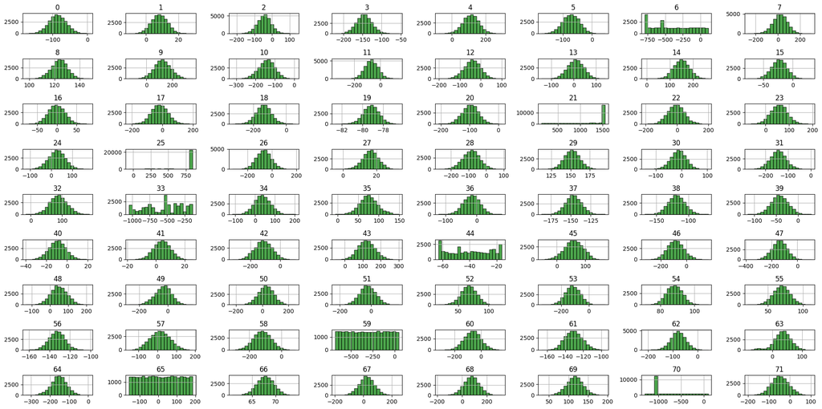

```python
%%time
show_histagram_matrix(df_base, n_bins=20, sample_frac=0.1)
```

Видно что нормальное распределение отсутствует в параметрах [6,21,25,33,44,59,65,70], т.е. всего 8 столбцов вызывают вопросы по распределению данных в них.

### Какие распределения в `df_train` у колонок?

[output not shown]

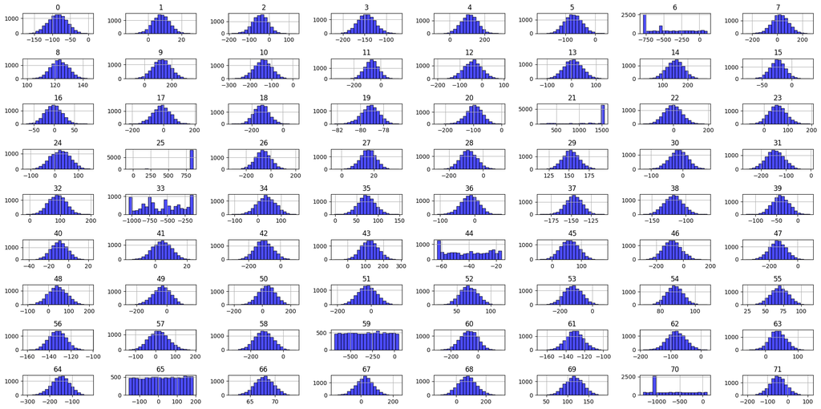

```
CPU times: user 14.7 s, sys: 240 ms, total: 14.9 s
Wall time: 15.8 s
```

```python
%%time
show_histagram_matrix(df_train, n_bins=20, color='b')
```

Видно что данные распределены похожим образом, как и в `df_base`.

### Какой разброс значений у признаков?

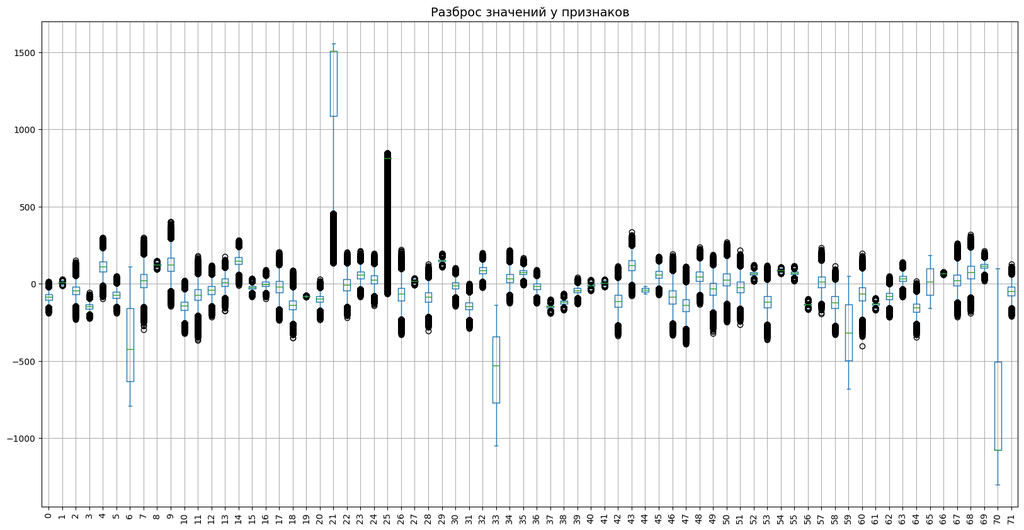

```
CPU times: user 2.51 s, sys: 242 ms, total: 2.75 s
Wall time: 2.65 s
```

```python
%%time
df_base.plot(kind='box', rot=90, grid=True, figsize=(20,10))
plt.title('Разброс значений у признаков', size=14)
plt.show()
```

Видно что признаки [6, 21, 33, 70] особенно сильно выделяются по отклонениям, гдето видны многочисленные выбросы, особенно их очень много в колонке 25.

**Есть ли сильно скоррелированные друг с другом столбцы?**

Возьмем для этого библиотеку phik (нравится мне она просто).

```python
def get_matrix_and_plot_phik(df:pd.DataFrame, figsize=(15, 10), cmap='binary', title=''):
  '''
  '''
  corr_matrix = df.phik_matrix(interval_cols=df.columns)

  plt.subplots(figsize=figsize)
  sns.heatmap(corr_matrix, cmap=cmap)
  plt.title(title)
  plt.show()

  return corr_matrix

def show_max_cor_5(matrix):
  '''
  '''
  print("Первые 5 самые большие корреляции пар:")
  return matrix[matrix < 1.0].max().sort_values(ascending=False).head()
```

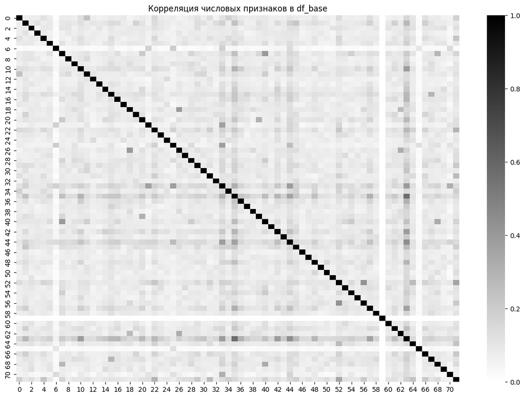

```
Первые 5 самые большие корреляции пар:
CPU times: user 5min 42s, sys: 7.41 s, total: 5min 50s
Wall time: 9min 14s
```

```
35    0.572070
63    0.572070
44    0.443510
56    0.427283
52    0.427283
dtype: float64
```

```python
%%time
cormatrix_base = get_matrix_and_plot_phik(df_base, title='Корреляция числовых признаков в df_base')
show_max_cor_5(cormatrix_base)
```

Видно что никакой связи между параметрами нет, т.е мультиколлинеарность не наблюдаем. Проверим еще на всякий тренировочный датасет.

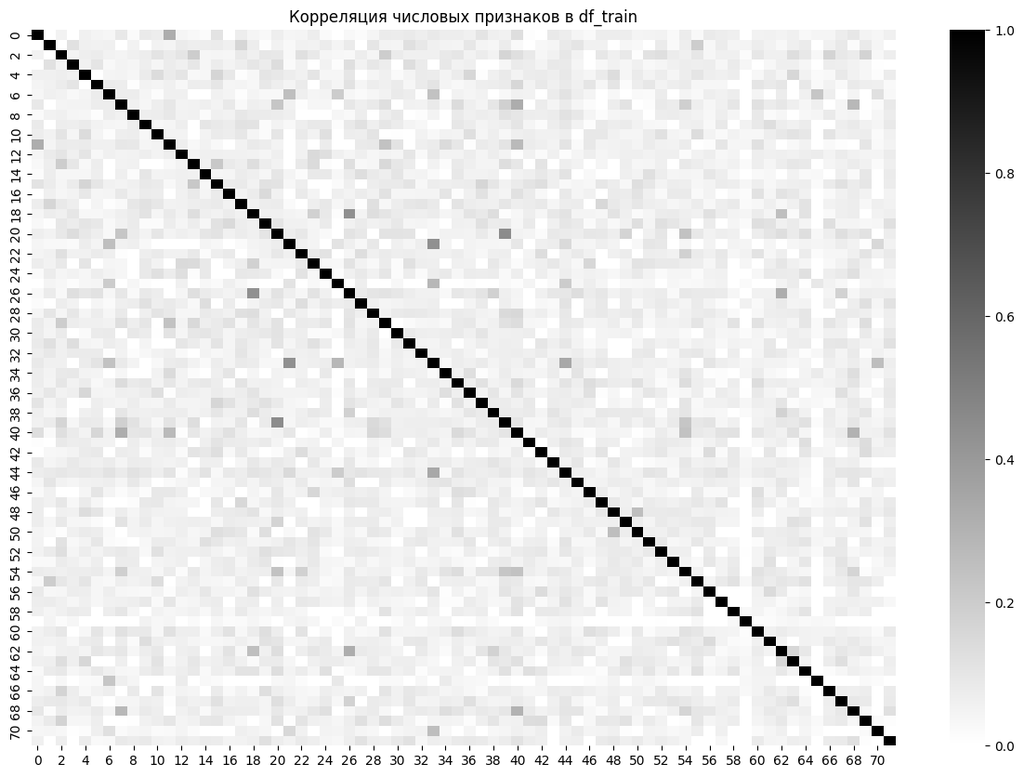

```
Первые 5 самые большие корреляции пар:
CPU times: user 8.86 s, sys: 237 ms, total: 9.09 s
Wall time: 28.6 s
```

```
20    0.450878
39    0.450878
33    0.434815
21    0.434815
26    0.433713
dtype: float64
```

```python
%%time
cormatrix_train = get_matrix_and_plot_phik(df_train, title='Корреляция числовых признаков в df_train')
show_max_cor_5(cormatrix_train)
```

Итого, мы можем уже ответить на все следующие вопросы:

**Все ли столбцы имеют одинаковое распределение значений?**  
-*Нет, столбцы [6, 21, 25, 33, 44, 59, 65, 70] имеют точно не нормальное распределение. Возможно после оценки важности признаков, после обучения модели мы поймем какие действительно наиболее важные, и подтвердим гипотезу по тому что какието из них возможно плохо влияют на конечный результат, но вначале стоит просто проверить метрику на другом маштабе, потом убрав эти столбцы также оценить влияние на результат, а дальше оценить важность каждого признака через модель (т.к. затратно по времени, обучение модели, отложу это вконец работы, если возьмем модель деревьев то можно вообще при оценке не маштабировать данные, в деревьях это бесполезно, не влияет на результат).*

**Есть ли столбцы, которые для модели были бы мало полезны?**  
-*Скорее всего это столбцы со странными хаотичными распределениями, отличными от нормальных, но нужно проверить на практике.*

**Есть ли сильно скоррелированные друг с другом столбцы?**  
-*Нет, нет таких столбцов.*

**Может быть, есть смысл на первом этапе подавать в модель не все фичи, а наиболее информативные?**  
-*Возможно, надо проверять.*

**Есть ли пропуски?**  
-*Нету.*

**Явные дубликаты?**  
-*Были, но они не влияли на метрику, т.к. дублировались и индексы, скорее они влияли немного на память загружаемую в ОЗУ, удалили такие записи.*

**Есть ли аномалии в распределениях?**  
-*Есть, какие-то столбцы сильно выделяются этим, в колонке 25 так вообще сплошные выбросы.*

**Не требуется ли масштабирование данных?**  
-*Масштабирование данных явно нужно, все параметры гуляют в разных пределах, самые большие пределы у [70,33,21,6], они явно будут сильно влиять на конечную шкалу при масштабировании, возможно стоить подумать избавиться сперва от них.*

## Масштабирование признаков

```python
scaler = RobustScaler()
```

```python
X_base = pd.DataFrame(scaler.fit_transform(df_base), index=df_base.index)
X_train = pd.DataFrame(scaler.transform(df_train), index=df_train.index)
X_valid = pd.DataFrame(scaler.transform(df_valid), index=df_valid.index)
```

## Считаем метрику на всех признаках после масштабирования данных

```python
%%time
idx_l2_allf = make_l2_idx(X_base, n_cells=20, n_probe=1)
acc_allf = get_accuracy_n(X_base, X_train, targets, idx_l2_allf)
print_accuracy_n(acc_allf)
```

```
Accuracy @ 5 = 48.7%
CPU times: user 10.4 s, sys: 258 ms, total: 10.7 s
Wall time: 6.57 s
```

```python
%%time
r, idx = idx_l2_allf.search(np.ascontiguousarray(df_train.values), OPTION_N_CANDIDATS)
```

```
CPU times: user 399 ms, sys: 0 ns, total: 399 ms
Wall time: 208 ms
```

## Считаем метрику теперь только на признаках с частью исключенных признаков с ненормальным распределением.

На данном этапе работ, в ходе подбора, к наибольшей метрики привело удаление следующих колонок. По хорошему же надо было с помощью модели, можно тогоже Решающего Леса оценить важность каждого признака, и аргументировать больше свой выбор, пока выбор основан на основе тупого долгого подбора, но уже за неимением времени приходится оставить так.

```python
del_columns = ['21', '25', '33', '59', '65']
X_base_norm = pd.DataFrame(scaler.fit_transform(df_base.drop(del_columns, axis=1)), index=df_base.index)
X_train_norm = pd.DataFrame(scaler.transform(df_train.drop(del_columns, axis=1)), index=df_train.index)
X_valid_norm = pd.DataFrame(scaler.transform(df_valid.drop(del_columns, axis=1)), index=df_valid.index)
```

```python
%%time
idx_l2_norm = make_l2_idx(X_base_norm, n_cells=20, n_probe=1)
acc_norm = get_accuracy_n(X_base_norm, X_train_norm, targets, idx_l2_norm)
print_accuracy_n(acc_norm)
```

```
Accuracy @ 5 = 68.3%
CPU times: user 7.2 s, sys: 234 ms, total: 7.43 s
Wall time: 4.03 s
```

Уже неплохие результаты, можно было бы еще обучить модель деревьев и оценить важность признаков, к томуже у нас есть еще и валидационная выборка чтобы оценивать такую модель, но так как времени уже не осталось, проведу простой перебор параметров, до нужной метрики в 70% совсем немного осталось.

```python
%%time
r, idx = idx_l2_norm.search(np.ascontiguousarray(X_train_norm.values), OPTION_N_CANDIDATS)
```

```
CPU times: user 6.52 s, sys: 9.95 ms, total: 6.53 s
Wall time: 5.53 s
```

Скорость поиска почему-то упала.

## Перебор параметров

*Так как нам важна немаловажно и скорость скорость то чем больше у нас значение n_cells тем лучше, можно возять перебор на вскидку с `n_cells=100`. Параметр же `nprobe` наоборот снижает скорость поиска, но зато повышает нашу точность, нужно оптимально как-то найти эти параметры.*

```python
# n_probe_start = 1
# n_probe_stop = 6
# n_cells_start = 100
# n_cells_stop = 120

# pars = []
# for nprobe in range(n_probe_start, n_probe_stop, 1):
#   print(f"n_probe={nprobe}:")
#   ncells_, acc_, hist_ = tuning_accuracy_n(X_base_norm, X_train_norm, targets, n_cells_start, n_cells_stop, n_probe=nprobe)
#   pars.append([nprobe, ncells_, acc_])

# pars_df = pd.DataFrame(pars, columns=['n_probe', 'n_cells', 'acc']).set_index(['n_probe','n_cells'])
# pars_df.sort_values(by='acc', ascending=False)
```

Возьмем навскидку для теста, такие параметры:

- **n_probe = 5**,
- **n_cells = 500**.

Найдем Accuracy @ 5 при таких параметрах, будем оценивать еще и скорость поиска.

```python
idx_l2_norm_2 = make_l2_idx(X_base_norm, n_cells=500, n_probe=5)
acc_norm = get_accuracy_n(X_base_norm, X_train_norm, targets, idx_l2_norm_2)
print_accuracy_n(acc_norm)
```

```
Accuracy @ 5 = 75.9%
```

```python
%%time
r, idx = idx_l2_norm_2.search(np.ascontiguousarray(X_train_norm.values), OPTION_N_CANDIDATS)
```

```
CPU times: user 1.49 s, sys: 4.86 ms, total: 1.49 s
Wall time: 798 ms
```

## Применяем алгоритм c лучшими параметрами на `df_valid`

```python
# idx_l2_norm_2 = make_l2_idx(X_base_norm, n_cells=500, n_probe=5)
acc_norm_v = get_accuracy_n(X_base_norm, X_valid_norm, answers, idx_l2_norm_2)
print_accuracy_n(acc_norm_v)
```

```
Accuracy @ 5 = 75.4%
```

```python
%%time
idx_l2_norm_2.search(np.ascontiguousarray(X_valid_norm.values), OPTION_N_CANDIDATS)
```

```
CPU times: user 1.5 s, sys: 10.7 ms, total: 1.51 s
Wall time: 836 ms
```

```
(array([[11.338832 , 13.119336 , 13.173825 , 13.175064 , 13.30193  ],
        [ 1.5568161, 23.412718 , 26.80118  , 28.230886 , 28.936594 ],
        [ 0.       , 21.46486  , 23.982874 , 25.857494 , 27.499933 ],
        ...,
        [ 3.699133 , 36.372658 , 36.812828 , 37.548748 , 37.78631  ],
        [ 2.370994 , 30.494322 , 32.03922  , 32.238995 , 32.581688 ],
        [ 0.       , 22.98584  , 28.470945 , 29.014101 , 30.419336 ]],
       dtype=float32),
 array([[155542, 163078, 273829, 242163,  56838],
        [  3786, 181149, 157572, 228265,  75620],
        [ 54931, 126599,  11844,  20783, 257601],
        ...,
        [ 65791,  70247,  79953, 231834, 241165],
        [138211, 153420, 213223, 115030, 174308],
        [149533,  46020,  47051, 262051, 123736]]))
```

## Итоговый вывод

**Результаты:**

Разработан алгоритм мэтчинга с метрикой Accuracy@5 ~= 75%. Поиск документов проходит относительно быстро.

**Accuracy@5 (на тренировочной выборке): 75.9%**

**Accuracy@5 (на валидационной выборке): 75.4%**

Параметры:

- *nprobe = 5*
- *n_cells = 500*

**Замечния:**

Во всех датафреймах обнаружили полные дубликаты:

- **df_base** - *11278 дубликатов*
- **df_train** - *243 дубликатов*
- **df_valid** - *265 дубликатов*
- **valid_answer** - *265 дубликатов (по индексам!).*

Были обнаружены признаки с ненормальными распределениями.

Были обнаружены выбросы почти во всех признаках (по диаграмме размаха).